# iDEP: Investigating Differentially Expressed Genes

## If this site has contributed to your work, please cite our article:

Ge, S.X., Son, E.W. & Yao, R. iDEP: an integrated web application for differential expression and pathway analysis of RNA-Seq data. BMC Bioinformatics 19, 534 (2018). https://doi.org/10.1186/s12859-018-2486-6

## Summary

Read Counts data were analyzed using iDEP v2.5.0. The data was first filtered to remove reads below 0.5 CPM in at least 1 sample. Then the data was transformed with EdgeR using a pseudocount of 4. Missing values were imputed using geneMedian.

After mapping, there are 17186 unique genes in 12 samples. Of the 14245 genes passed filter, 14245 were converted to Ensembl/STRING gene IDs in our database. The remaining 0 genes were kept in the data using original IDs.

Differential expression analysis was performed using DESeq2 with an FDR cutoff of 0.05 and a minimum fold-change threshold of 2. Standard Wald test was used and independent filtering was enabled.

## Selected Comparison: INFECTED-CONTROL

Up-regulated genes: 302

Down-regulated genes: 56

## Top Up-regulated Genes

```r
if (!is.null(params$up_genes_table) && nrow(params$up_genes_table) > 0) {
  kbl(params$up_genes_table, escape = FALSE) %>%
    kable_classic(full_width = FALSE, html_font = "Cambria")
} else {
  print("No up-regulated genes found for this comparison.")
}
```

| Symbol | Ensembl ID | log2 FC | Adj. P-value | Description |
| --- | --- | --- | --- | --- |
| Ccl3 | ENSMUSG00000000982 | 3.745 | 9.72e-03 | C-C motif chemokine ligand 3 |
| Serpina3f | ENSMUSG00000066363 | 3.687 | 2.51e-03 | Serine (or cysteine) peptidase inhibitor, clade A, member 3F |
| Slfn1 | ENSMUSG00000078763 | 3.561 | 3.14e-06 | Schlafen 1 |
| Gzmb | ENSMUSG00000015437 | 3.428 | 3.62e-04 | Granzyme B |
| Clec4d | ENSMUSG00000030144 | 3.425 | 5.10e-03 | C-type lectin domain family 4, member d |
| Zbp1 | ENSMUSG00000027514 | 3.354 | 2.10e-09 | Z-DNA binding protein 1 |
| Sprr1a | ENSMUSG00000050359 | 3.334 | 1.26e-04 | Small proline-rich protein 1A |
| Scimp | ENSMUSG00000057135 | 3.323 | 5.02e-04 | SLP adaptor and CSK interacting membrane protein |
| Serpina3g | ENSMUSG00000041481 | 3.272 | 2.23e-05 | Serine (or cysteine) peptidase inhibitor, clade A, member 3G |
| Gzma | ENSMUSG00000023132 | 3.240 | 2.00e-11 | Granzyme A |
| Ccl5 | ENSMUSG00000035042 | 3.168 | 1.09e-17 | C-C motif chemokine ligand 5 |
| Apol9b | ENSMUSG00000068246 | 3.154 | 2.49e-05 | Apolipoprotein L 9b |
| Il1rn | ENSMUSG00000026981 | 3.086 | 4.02e-03 | Interleukin 1 receptor antagonist |
| Plac8 | ENSMUSG00000029322 | 3.064 | 5.15e-05 | Placenta-specific 8 |
| Lcn2 | ENSMUSG00000026822 | 3.053 | 2.48e-09 | Lipocalin 2 |
| Gm4841 | ENSMUSG00000068606 | 3.046 | 1.09e-05 | Predicted gene 4841 |
| Mx1 | ENSMUSG00000000386 | 3.033 | 1.93e-03 | MX dynamin-like GTPase 1 |
| Nkg7 | ENSMUSG00000004612 | 3.020 | 4.39e-07 | Natural killer cell group 7 sequence |
| Ccl8 | ENSMUSG00000009185 | 3.020 | 7.76e-06 | C-C motif chemokine ligand 8 |
| Ifi206 | ENSMUSG00000037849 | 3.003 | 1.55e-03 | Interferon activated gene 206 |
| Ifit3 | ENSMUSG00000074896 | 2.998 | 1.75e-10 | Interferon-induced protein with tetratricopeptide repeats 3 |
| F830016B08Rik | ENSMUSG00000090942 | 2.984 | 2.31e-06 | RIKEN cDNA F830016B08 gene |
| Ccl12 | ENSMUSG00000035352 | 2.961 | 4.17e-05 | C-C motif chemokine ligand 12 |
| Ch25h | ENSMUSG00000050370 | 2.956 | 2.01e-03 | Cholesterol 25-hydroxylase |
| Chil3 | ENSMUSG00000040809 | 2.954 | 6.30e-04 | Chitinase-like 3 |
| Oasl1 | ENSMUSG00000041827 | 2.942 | 2.71e-05 | 2’-5’ oligoadenylate synthetase-like 1 |
| Oas3 | ENSMUSG00000032661 | 2.941 | 8.44e-05 | 2’-5’ oligoadenylate synthetase 3 |
| Lgals3 | ENSMUSG00000050335 | 2.899 | 1.56e-07 | Lectin, galactose binding, soluble 3 |
| Apol9a | ENSMUSG00000057346 | 2.889 | 7.32e-06 | Apolipoprotein L 9a |
| Ly6i | ENSMUSG00000022586 | 2.882 | 1.72e-02 | Lymphocyte antigen 6 family member I |
| Klrb1c | ENSMUSG00000030325 | 2.857 | 1.21e-02 | Killer cell lectin-like receptor subfamily B member 1C |
| Ifi209 | ENSMUSG00000043263 | 2.856 | 1.84e-05 | Interferon activated gene 209 |
| Timp1 | ENSMUSG00000001131 | 2.825 | 4.28e-04 | Tissue inhibitor of metalloproteinase 1 |
| C4a | ENSMUSG00000015451 | 2.815 | 9.47e-12 | Complement C4A (Rodgers blood group) |
| Phf11b | ENSMUSG00000091649 | 2.800 | 1.23e-07 | PHD finger protein 11B |
| Ifit3b | ENSMUSG00000062488 | 2.795 | 9.18e-18 | Interferon-induced protein with tetratricopeptide repeats 3B |
| Ms4a4c | ENSMUSG00000024675 | 2.786 | 4.43e-03 | Membrane-spanning 4-domains, subfamily A, member 4C |
| Cxcl10 | ENSMUSG00000034855 | 2.785 | 1.00e-03 | C-X-C motif chemokine ligand 10 |
| Irf7 | ENSMUSG00000025498 | 2.762 | 1.37e-42 | Interferon regulatory factor 7 |
| Klra2 | ENSMUSG00000030187 | 2.751 | 5.09e-03 | Killer cell lectin-like receptor, subfamily A, member 2 |
| Fcgr4 | ENSMUSG00000059089 | 2.705 | 1.19e-06 | Fc receptor, IgG, low affinity IV |
| Batf | ENSMUSG00000034266 | 2.660 | 2.22e-02 | Basic leucine zipper transcription factor, ATF-like |
| Ccl4 | ENSMUSG00000018930 | 2.651 | 2.37e-02 | C-C motif chemokine ligand 4 |
| Hck | ENSMUSG00000003283 | 2.634 | 1.10e-05 | Hemopoietic cell kinase |
| Acod1 | ENSMUSG00000022126 | 2.633 | 2.17e-02 | Aconitate decarboxylase 1 |
| Ifitm6 | ENSMUSG00000059108 | 2.625 | 1.55e-02 | Interferon induced transmembrane protein 6 |
| Slfn4 | ENSMUSG00000000204 | 2.621 | 1.33e-03 | Schlafen 4 |
| Ccl2 | ENSMUSG00000035385 | 2.614 | 2.55e-03 | C-C motif chemokine ligand 2 |
| Ptx3 | ENSMUSG00000027832 | 2.612 | 1.67e-02 | Pentraxin related gene |
| Ifit2 | ENSMUSG00000045932 | 2.602 | 9.48e-12 | Interferon-induced protein with tetratricopeptide repeats 2 |

## Top Down-regulated Genes

```r
if (!is.null(params$down_genes_table) && nrow(params$down_genes_table) > 0) {
  kbl(params$down_genes_table, escape = FALSE) %>%
    kable_classic(full_width = FALSE, html_font = "Cambria")
} else {
  print("No down-regulated genes found for this comparison.")
}
```

| Symbol | Ensembl ID | log2 FC | Adj. P-value | Description |
| --- | --- | --- | --- | --- |
| Hba-a1 | ENSMUSG00000069919 | -3.115 | 3.53e-04 | Hemoglobin alpha, adult chain 1 |
| Hba-a2 | ENSMUSG00000069917 | -3.110 | 3.38e-04 | Hemoglobin alpha, adult chain 2 |
| Snca | ENSMUSG00000025889 | -3.011 | 4.78e-03 | Synuclein, alpha |
| Hbb-bt | ENSMUSG00000073940 | -2.763 | 1.24e-03 | Hemoglobin, beta adult t chain |
| Alas2 | ENSMUSG00000025270 | -2.724 | 1.94e-03 | Aminolevulinic acid synthase 2, erythroid |
| Duox1 | ENSMUSG00000033268 | -2.708 | 4.68e-02 | Dual oxidase 1 |
| Tent5c | ENSMUSG00000044468 | -2.703 | 1.42e-03 | Terminal nucleotidyltransferase 5C |
| Hbb-bs | ENSMUSG00000052305 | -2.604 | 4.98e-04 | Hemoglobin, beta adult s chain |
| Sez6l2 | ENSMUSG00000030683 | -2.132 | 8.21e-04 | Seizure related 6 homolog like 2 |
| Crybb1 | ENSMUSG00000029343 | -2.068 | 3.17e-03 | Crystallin, beta B1 |
| Tafa3 | ENSMUSG00000055865 | -1.852 | 4.17e-02 | TAFA chemokine like family member 3 |
| Pcdh12 | ENSMUSG00000024440 | -1.835 | 4.26e-05 | Protocadherin 12 |
| Pnmt | ENSMUSG00000038216 | -1.828 | 2.48e-06 | Phenylethanolamine-N-methyltransferase |
| Krt10 | ENSMUSG00000019761 | -1.769 | 3.28e-02 | Keratin 10 |
| Tfrc | ENSMUSG00000022797 | -1.768 | 1.80e-06 | Transferrin receptor |
| Aplnr | ENSMUSG00000044338 | -1.756 | 7.31e-08 | Apelin receptor |
| Cryba4 | ENSMUSG00000066975 | -1.660 | 5.10e-06 | Crystallin, beta A4 |
| Cabp1 | ENSMUSG00000029544 | -1.640 | 2.12e-02 | Calcium binding protein 1 |
| Apln | ENSMUSG00000037010 | -1.639 | 5.20e-05 | Apelin |
| Retnla | ENSMUSG00000061100 | -1.627 | 2.86e-04 | Resistin like alpha |
| Ret | ENSMUSG00000030110 | -1.536 | 1.90e-02 | Ret proto-oncogene |
| Adamts9 | ENSMUSG00000030022 | -1.532 | 7.26e-05 | ADAM metallopeptidase with thrombospondin type 1 motif 9 |
| Ldlrad3 | ENSMUSG00000048058 | -1.520 | 3.51e-03 | Low density lipoprotein receptor class A domain containing 3 |
| Bpgm | ENSMUSG00000038871 | -1.497 | 1.38e-02 | 2,3-bisphosphoglycerate mutase |
| Kit | ENSMUSG00000005672 | -1.483 | 3.12e-02 | KIT proto-oncogene receptor tyrosine kinase |
| Plxnd1 | ENSMUSG00000030123 | -1.479 | 6.98e-03 | Plexin D1 |
| Lypd2 | ENSMUSG00000022595 | -1.472 | 8.47e-03 | Ly6/Plaur domain containing 2 |
| Arc | ENSMUSG00000022602 | -1.440 | 4.19e-02 | Activity regulated cytoskeletal-associated protein |
| Nrep | ENSMUSG00000042834 | -1.357 | 2.54e-09 | Neuronal regeneration related protein |
| Drd2 | ENSMUSG00000032259 | -1.329 | 1.13e-02 | Dopamine receptor D2 |
| Dbh | ENSMUSG00000000889 | -1.327 | 3.77e-07 | Dopamine beta hydroxylase |
| Tmem150c | ENSMUSG00000050640 | -1.315 | 5.84e-04 | Transmembrane protein 150C |
| Slc25a37 | ENSMUSG00000034248 | -1.293 | 2.98e-03 | Solute carrier family 25, member 37 |
| Vps13a | ENSMUSG00000046230 | -1.271 | 5.33e-03 | Vacuolar protein sorting 13A |
| Igsf1 | ENSMUSG00000031111 | -1.263 | 4.96e-06 | Immunoglobulin superfamily, member 1 |
| Klhdc8a | ENSMUSG00000042115 | -1.253 | 4.94e-05 | Kelch domain containing 8A |
| Nes | ENSMUSG00000004891 | -1.238 | 2.42e-03 | Nestin |
| Phkg1 | ENSMUSG00000025537 | -1.206 | 2.18e-03 | Phosphorylase kinase gamma 1 |
| Ppargc1b | ENSMUSG00000033871 | -1.196 | 1.17e-02 | Peroxisome proliferative activated receptor, gamma, coactivator 1 beta |
| Dok4 | ENSMUSG00000040631 | -1.161 | 1.67e-02 | Docking protein 4 |
| Nrarp | ENSMUSG00000078202 | -1.160 | 1.16e-04 | Notch-regulated ankyrin repeat protein |
| Scn4b | ENSMUSG00000046480 | -1.117 | 1.63e-06 | Sodium channel, type IV, beta |
| Bcl6b | ENSMUSG00000000317 | -1.116 | 1.59e-02 | B cell CLL/lymphoma 6, member B |
| Metrn | ENSMUSG00000002274 | -1.109 | 2.83e-10 | Meteorin, glial cell differentiation regulator |
| Slc22a3 | ENSMUSG00000023828 | -1.106 | 9.19e-03 | Solute carrier family 22 (organic cation transporter), member 3 |
| Fam81a | ENSMUSG00000032224 | -1.097 | 1.88e-03 | Family with sequence similarity 81, member A |
| Dnai7 | ENSMUSG00000043541 | -1.091 | 7.76e-03 | Dynein axonemal intermediate chain 7 |
| Itgb6 | ENSMUSG00000026971 | -1.078 | 9.28e-03 | Integrin beta 6 |
| Col4a4 | ENSMUSG00000067158 | -1.074 | 1.55e-02 | Collagen, type IV, alpha 4 |
| Cenpf | ENSMUSG00000026605 | -1.065 | 1.90e-03 | Centromere protein F |

## DEG Heatmap

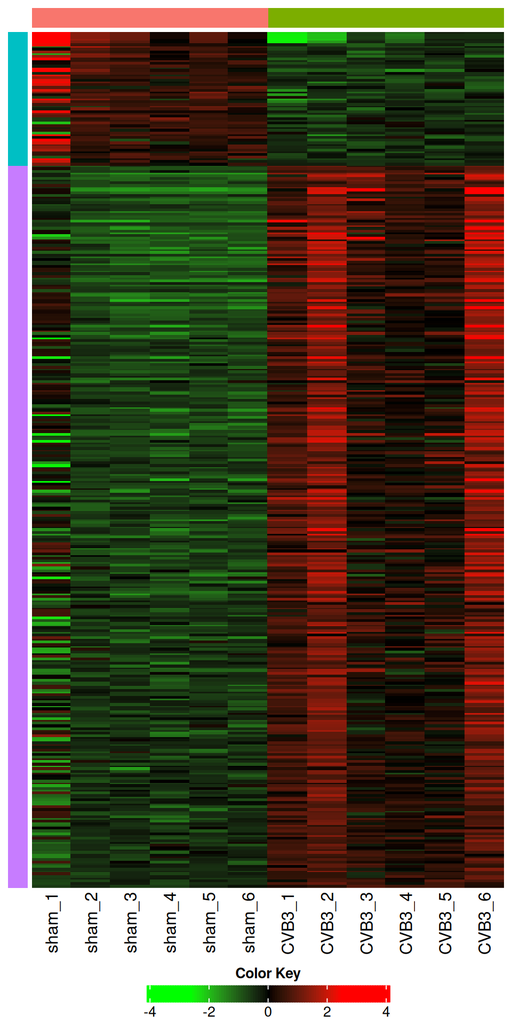

```r
if (!is.null(params$heat_data) && !is.null(params$heat_bar)) {
  heat_colors <- unlist(strsplit(params$heatmap_color_select, "-"))

  deg_heatmap(
    df = params$heat_data,
    bar = params$heat_bar,
    heatmap_color_select = heat_colors,
    cluster_rows = FALSE
  )
}
```

## Volcano Plot

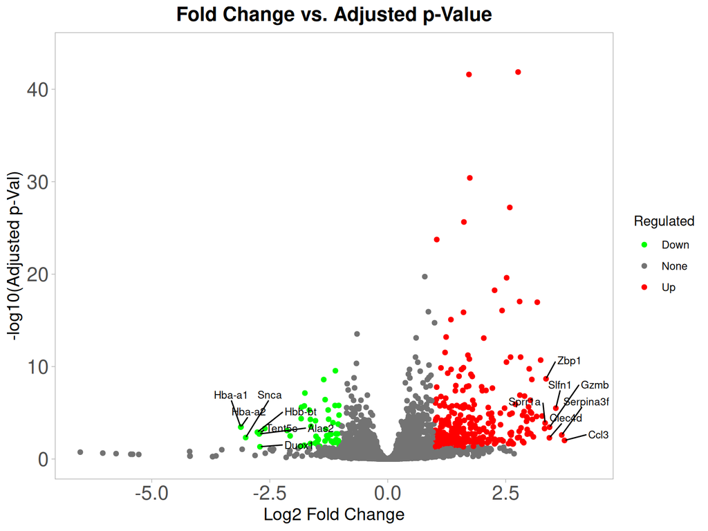

```r
if (!is.null(params$vol_data) && !is.null(params$vol_data$data)) {
  p <- plot_volcano(
    data = params$vol_data$data,
    plot_colors = params$plot_colors,
    anotate_genes = params$gene_labels_volcano
  )
  p <- refine_ggplot2(
    p = p,
    gridline = params$plot_grid_lines,
    ggplot2_theme = params$ggplot2_theme
  )
  print(p)
}
```

## MA Plot

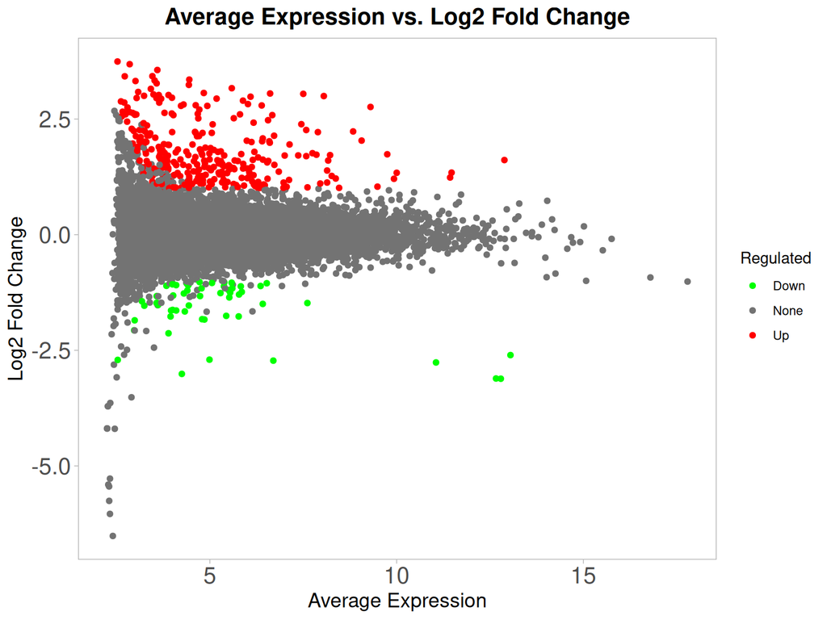

```r
if (!is.null(params$vol_data) && !is.null(params$vol_data$data)) {
  p <- plot_ma(
    data = params$vol_data$data,
    plot_colors = params$plot_colors,
    anotate_genes = params$gene_labels_ma
  )
  p <- refine_ggplot2(
    p = p,
    gridline = params$plot_grid_lines,
    ggplot2_theme = params$ggplot2_theme
  )
  print(p)
}
```

## Scatter Plot

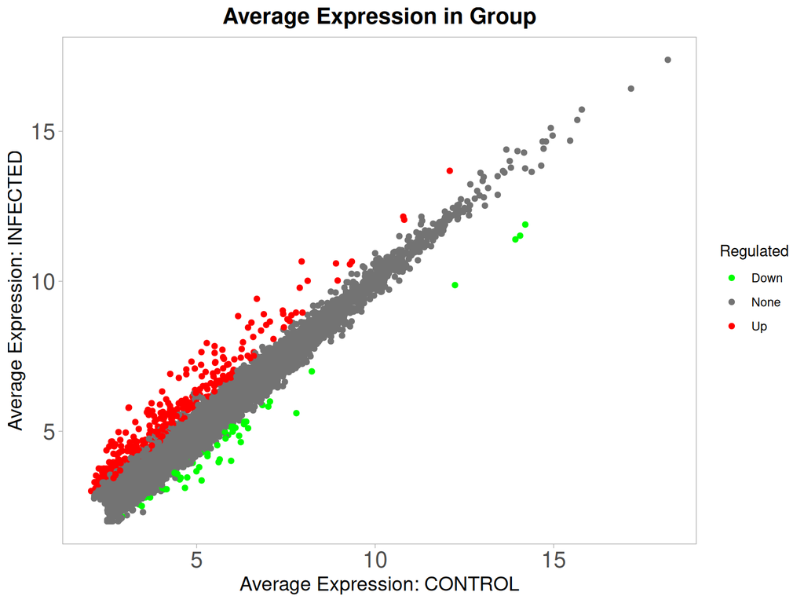

```r
if (!is.null(params$top_genes) && !is.null(params$comparisons)) {
  p <- plot_deg_scatter(
    select_contrast = params$select_contrast,
    comparisons = params$comparisons,
    top_genes = params$top_genes,
    limma_p_val = params$limma_p_val,
    limma_fc = params$limma_fc,
    contrast_samples = params$contrast_samples,
    processed_data = params$processed_data,
    sample_info = params$sample_info,
    plot_colors = params$plot_colors,
    all_gene_names = params$all_gene_names,
    select_gene_id = params$select_gene_id,
    anotate_genes = params$gene_labels_scatter
  )
  p <- refine_ggplot2(
    p = p,
    gridline = params$plot_grid_lines,
    ggplot2_theme = params$ggplot2_theme
  )
  print(p)
}
```

Generated using iDEP v2.5.0 (https://bioinformatics.sdstate.edu/idep). 2026-09-27 15:35:34 UTC. Accuracy not guaranteed.